# Analogous Experiment 2 - Results

# Descriptives

## Overall descriptives

```r
psych::describe(long_data)
```

```
##                             vars     n     mean       sd   median  trimmed
## sub_id                         1 22812   176.08   104.58   175.00   175.51
## duration_seconds               2 22812  4922.41 31187.62  1648.00  1746.47
## recorded_date                  3 22812      NaN       NA       NA      NaN
## age                            4 22736    19.43     2.03    19.00    19.03
## gender*                        5 22812     1.37     0.58     1.00     1.28
## ethnicity*                     6 22812     5.10     1.56     6.00     5.33
## cand_pref*                     7 22812     1.09     0.28     1.00     1.00
## ingroup_ident                  8 22736     3.27     0.95     3.00     3.32
## threat                         9 22736     3.27     1.30     3.00     3.33
## sona_id                       10 22812 50727.07  1510.16 51263.00 51055.79
## bfi_number*                   11 22812    10.00     5.48    10.00    10.00
## self                          12 22788     3.26     1.28     3.00     3.33
## target_number_in_condition*   13 22812     3.33     0.75     3.00     3.45
## target_bfi_value              14 22812     3.00     1.14     3.00     3.00
## condition_order*              15 22812     1.50     0.50     1.00     1.50
## political_ident*              16 22812     2.31     0.69     2.00     2.26
## covid1*                       17 22812     1.86     0.35     2.00     1.95
## covid2                        18 22812     2.24     1.25     2.00     2.02
## covid3*                       19 22812     2.02     0.99     2.00     2.01
## target_bfi_number*            20 22812    10.00     5.48    10.00    10.00
## mancheck*                     21 22812     1.00     0.00     1.00     1.00
## target_number_collapsed*      22 22812     1.50     0.50     2.00     1.50
## target_group*                 23 22812     1.91     0.28     2.00     2.00
## ingroup_ident_c               24 22736     0.00     0.95    -0.27     0.05
## threat_c                      25 22736     0.00     1.30    -0.27     0.07
## self_c                        26 22788     0.00     1.28    -0.26     0.07
##                                mad      min       max  range  skew kurtosis
## sub_id                      134.92     1.00    362.00    361  0.03    -1.23
## duration_seconds            659.76   506.00 415328.00 414822 11.67   139.43
## recorded_date                   NA      Inf      -Inf   -Inf    NA       NA
## age                           1.48    18.00     32.00     14  3.31    14.22
## gender*                       0.00     1.00      5.00      4  1.85     5.45
## ethnicity*                    0.00     1.00      8.00      7 -1.08    -0.13
## cand_pref*                    0.00     1.00      2.00      1  2.94     6.66
## ingroup_ident                 1.48     1.00      5.00      4 -0.46     0.06
## threat                        1.48     1.00      5.00      4 -0.17    -1.07
## sona_id                     566.35 41036.00  51843.00  10807 -3.01    11.37
## bfi_number*                   7.41     1.00     19.00     18  0.00    -1.21
## self                          1.48     1.00      5.00      4 -0.25    -1.08
```

[output cut: 26 more lines]

```
## self                          0.01
## target_number_in_condition*   0.00
## target_bfi_value              0.01
## condition_order*              0.00
## political_ident*              0.00
## covid1*                       0.00
## covid2                        0.01
## covid3*                       0.01
## target_bfi_number*            0.04
## mancheck*                     0.00
## target_number_collapsed*      0.00
## target_group*                 0.00
## ingroup_ident_c               0.01
## threat_c                      0.01
## self_c                        0.01
```

## Histograms

### Confirmatory

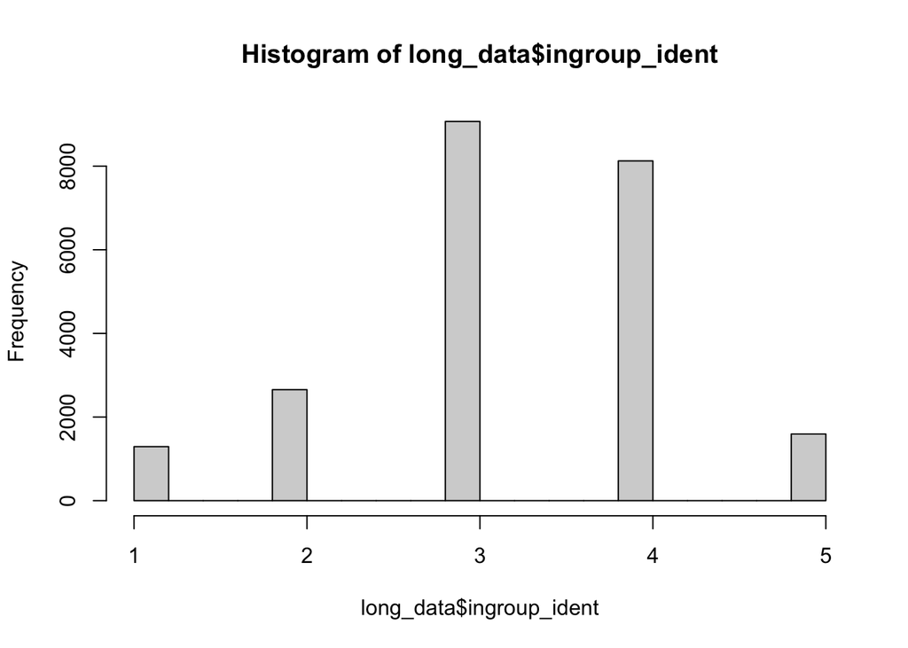

```r
hist(long_data$ingroup_ident)
```

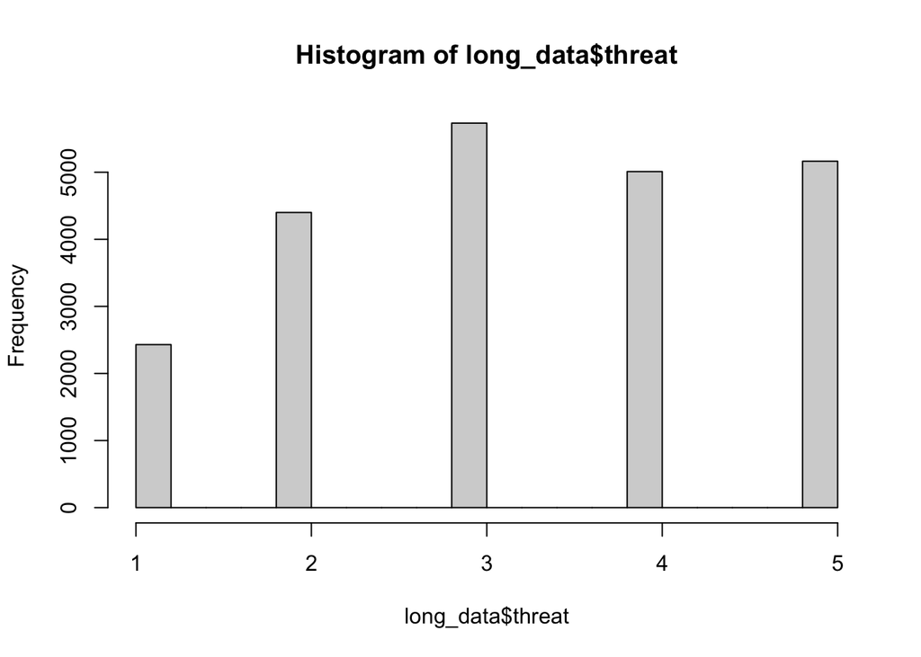

```r
hist(long_data$threat)
```

```r
long_data %>%
  select(sub_id, threat) %>%
  unique() %>%
  group_by(threat) %>%
  count()
```

```
## # A tibble: 6 × 2
## # Groups:   threat [6]
##   threat     n
##    <dbl> <int>
## 1      1    32
## 2      2    58
## 3      3    76
## 4      4    66
## 5      5    68
## 6     NA     1
```

```r
long_data %>%
  select(sub_id, threat_c) %>%
  unique() %>%
  group_by(threat_c) %>%
  count()
```

```
## # A tibble: 6 × 2
## # Groups:   threat_c [6]
##   threat_c     n
##      <dbl> <int>
## 1   -2.27     32
## 2   -1.27     58
## 3   -0.267    76
## 4    0.733    66
## 5    1.73     68
## 6   NA         1
```

Identification is roughly normal, while threat is closer to flat.

## Boxplots

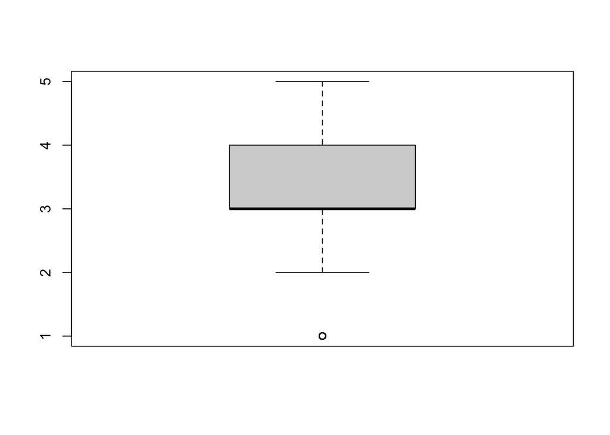

```r
box_ident_res <- boxplot(long_data$ingroup_ident)
```

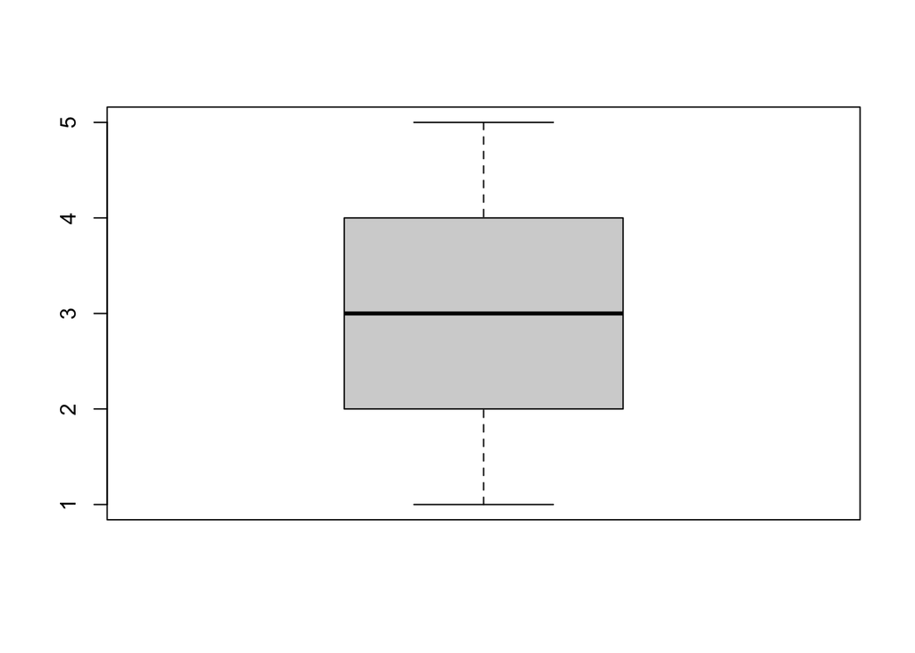

```r
boxplot(long_data$threat)
```

```r
range(box_ident_res$out)
```

```
## [1] 1 1
```

```r
sd <- round(sd(na.omit(long_data$ingroup_ident)),2)
mean <- round(mean(na.omit(long_data$ingroup_ident)),2)
upper_cut <- mean + 3*sd
lower_cut <- mean - 3*sd

long_data %>%
  select(sub_id, ingroup_ident) %>%
  unique() %>%
  filter(ingroup_ident < lower_cut | ingroup_ident > upper_cut)
```

```
## # A tibble: 0 × 2
## # … with 2 variables: sub_id <int>, ingroup_ident <dbl>
```

The outliers are not over our criteria of 3 SD so they will not be removed. Plus, they are theoretically important as the weakly identified individuals.

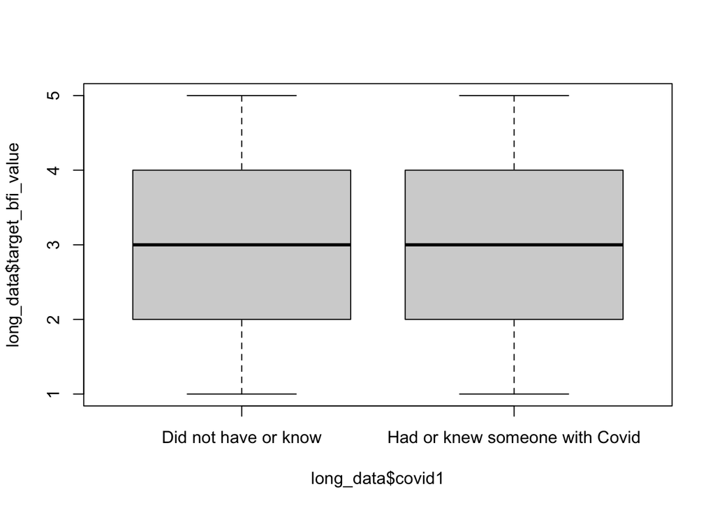

```r
boxplot(long_data$target_bfi_value ~ long_data$covid1)
```

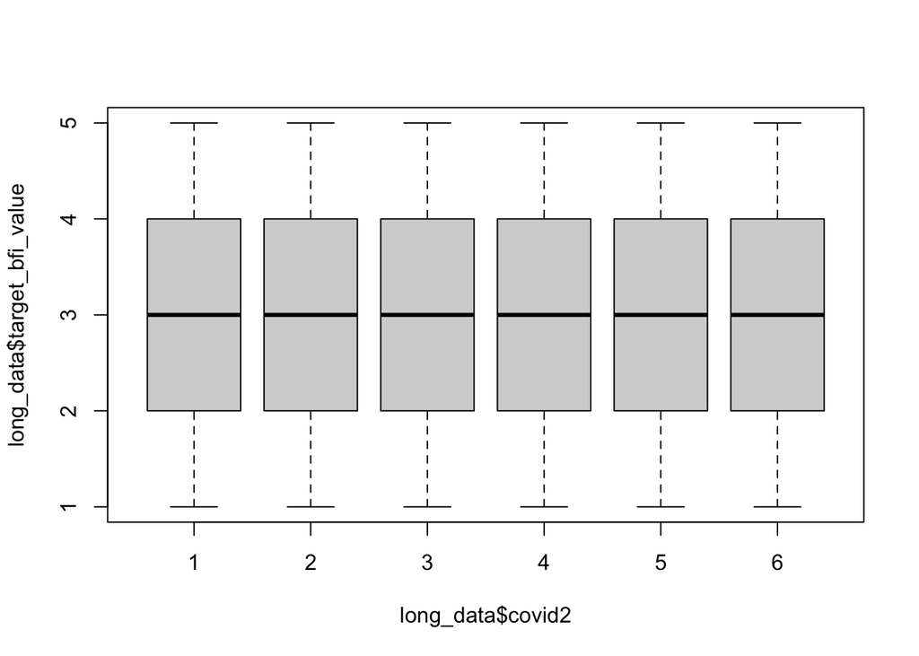

```r
boxplot(long_data$target_bfi_value ~ long_data$covid2)
```

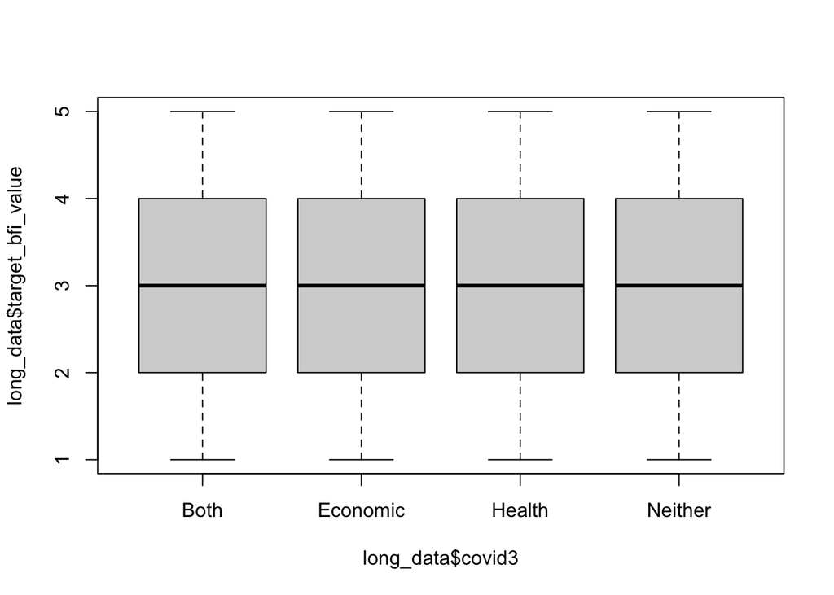

```r
boxplot(long_data$target_bfi_value ~ long_data$covid3)
```

# Demographics

## Sample Size

### Before removing listwise:

```r
long_data %>%
  select(sub_id) %>%
  unique() %>%
  nrow()
```

```
## [1] 301
```

### Listwise removal:

*Data used in rest of demographics*

```r
# Listwise removal of missing data per item
model_data <- long_data %>%
  select(sub_id, bfi_number, cand_pref, ingroup_ident, threat,
         self, target_number_collapsed, target_bfi_value,
         condition_order, covid1, covid2, covid3, target_group,
         ingroup_ident_c, self_c, threat_c, gender, ethnicity, political_ident) %>%
  drop_na()
```

```r
model_data %>%
  select(sub_id) %>%
  unique() %>%
  nrow()
```

```
## [1] 300
```

## Political demographics

### N per Voting Opinion

```r
model_data %>%
  select(sub_id, cand_pref) %>%
  unique() %>%
  group_by(cand_pref) %>%
  count()
```

```
## # A tibble: 2 × 2
## # Groups:   cand_pref [2]
##   cand_pref               n
##   <fct>               <int>
## 1 Not Trump Supporter   274
## 2 Trump Supporter        26
```

I’m wondering with so few Trump supporters if we should remove them from the analysis… There isn’t enough for a comparison condition

### Self-reported political leaning

```r
model_data %>%
  select(sub_id, political_ident) %>%
  unique() %>%
  group_by(political_ident) %>%
  count()
```

```
## # A tibble: 4 × 2
## # Groups:   political_ident [4]
##   political_ident         n
##   <fct>               <int>
## 1 conservative           19
## 2 progressive/liberal   187
## 3 moderate               74
## 4 other                  20
```

## Gender

```r
model_data %>%
  na.omit() %>%
  select(sub_id, gender) %>%
  unique() %>%
  group_by(gender) %>%
  count()
```

```
## # A tibble: 5 × 2
## # Groups:   gender [5]
##   gender                n
##   <fct>             <int>
## 1 Female              203
## 2 Male                 88
## 3 Non-Binary            7
## 4 Self-describe         1
## 5 Prefer not to say     1
```

## Race/Ethnicity

```r
ethnicity_counts <- model_data %>%
  select(sub_id, ethnicity) %>%
  na.omit() %>%
  unique() %>%
  group_by(ethnicity) %>%
  count()

ethnicity_counts %>%
  mutate(n_total = sum(ethnicity_counts$n),
    percent = n/n_total*100) %>%
  select(-n_total)
```

```
## # A tibble: 8 × 3
## # Groups:   ethnicity [8]
##   ethnicity                           n percent
##   <fct>                           <int>   <dbl>
## 1 American Indian/Alaska Native       3   1
## 2 Asian                              39  13
## 3 Black/African American             12   4
## 4 Hispanic or Latino/a               39  13
## 5 Middle Eastern or North African     2   0.667
## 6 White                             193  64.3
## 7 Other                               9   3
## 8 Prefer not to answer                3   1
```

## Age

```r
long_data %>%
  select(sub_id, age) %>%
  na.omit() %>%
  summarize(mean = mean(age),
            sd = sd(age))
```

```
## # A tibble: 1 × 2
##    mean    sd
##   <dbl> <dbl>
## 1  19.4  2.03
```

*Age uses long_data due to removing more data*

## COVID Questions

### Personal experience with COVID

```r
model_data %>%
  select(sub_id, covid1) %>%
  unique() %>%
  group_by(covid1) %>%
  count()
```

```
## # A tibble: 2 × 2
## # Groups:   covid1 [2]
##   covid1                             n
##   <fct>                          <int>
## 1 Did not have or know              43
## 2 Had or knew someone with Covid   257
```

### How many people they see

```r
model_data %>%
  select(sub_id, covid2) %>%
  unique() %>%
  mutate(covid2 = recode(covid2,
                         `1` = "0 to 2 people",
                         `2` = "3 to 6 people",
                         `3` = "7 to 10 people",
                         `4` = "11 to 15 people",
                         `5` = "16 to 20 people",
                         `6` = "21 or more people")) %>%
  group_by(covid2) %>%
  count()
```

```
## # A tibble: 6 × 2
## # Groups:   covid2 [6]
##   covid2                n
##   <chr>             <int>
## 1 0 to 2 people        84
## 2 11 to 15 people      12
## 3 16 to 20 people       5
## 4 21 or more people    15
## 5 3 to 6 people       129
## 6 7 to 10 people       55
```

### Most important issue related to COVID

```r
model_data %>%
  select(sub_id, covid3) %>%
  unique() %>%
  group_by(covid3) %>%
  count()
```

```
## # A tibble: 4 × 2
## # Groups:   covid3 [4]
##   covid3       n
##   <fct>    <int>
## 1 Both       140
## 2 Economic    15
## 3 Health     142
## 4 Neither      3
```

# Model Comparisons

## Contrasts

### Target number

```r
## Dummy coding with first target as reference as wanted
contrasts(model_data$target_number_collapsed)
```

```
##          target_2
## target_1        0
## target_2        1
```

### Target group

```r
## Levels for target group were opposite, so switched them and applied effects coding
## for between-subjects differences of target (which is based on political preference
## - it is the opposite of the target's preference)
levels(model_data$target_group)
```

```
## [1] "Not Trump Supporter Target" "Trump Supporter Target"
```

```r
model_data$target_group <- relevel(model_data$target_group, "Trump Supporter Target")
contrasts(model_data$target_group) <- contr.sum(2)
```

## Base Model

```r
# For reference about nesting: https://www.muscardinus.be/2017/07/lme4-random-effects/
model_base <- lmer(target_bfi_value ~ self_c*target_number_collapsed + (self_c|sub_id), data = model_data)

tab_model(model_base,
          digits = 3)
```

|  | target_bfi_value |  |  |
| --- | --- | --- | --- |
| Predictors | Estimates | CI | p |
| (Intercept) | 2.971 | 2.941 – 3.000 | **<0.001** |
| self c | -0.070 | -0.104 – -0.036 | **<0.001** |
| target number collapsed [target 2] | 0.084 | 0.056 – 0.112 | **<0.001** |
| self c * target number collapsed [target 2] | 0.079 | 0.058 – 0.101 | **<0.001** |
| Random Effects |  |  |  |
| σ<sup>2</sup> | 1.14 |  |  |
| τ<sub>00</sub> <sub>sub_id</sub> | 0.04 |  |  |
| τ<sub>11</sub> <sub>sub_id.self_c</sub> | 0.07 |  |  |
| ρ<sub>01</sub> <sub>sub_id</sub> | 0.36 |  |  |
| ICC | 0.12 |  |  |
| N <sub>sub_id</sub> | 300 |  |  |
| Observations | 22712 |  |  |
| Marginal R<sup>2</sup> / Conditional R<sup>2</sup> | 0.004 / 0.123 |  |  |

```r
# Model adding RE for target_number_collapsed at this level did not converge
# mod_vartest_targ <- lmer(target_bfi_value ~ self_c*target_number_collapsed + (self_c + target_number_collapsed|sub_id), data = model_data)
```

### Simple slopes

```r
emms_slopes_base <- emtrends(model_base, ~ target_number_collapsed, var = "self_c")
emms_slopes_base
```

```
##  target_number_collapsed self_c.trend     SE  df asymp.LCL asymp.UCL
##  target_1                    -0.06980 0.0174 Inf   -0.1040   -0.0356
##  target_2                     0.00952 0.0175 Inf   -0.0247    0.0437
##
## Degrees-of-freedom method: asymptotic
## Confidence level used: 0.95
```

#### With p-value

```r
test(emms_slopes_base)
```

```
##  target_number_collapsed self_c.trend     SE  df z.ratio p.value
##  target_1                    -0.06980 0.0174 Inf  -4.000  0.0001
##  target_2                     0.00952 0.0175 Inf   0.546  0.5852
##
## Degrees-of-freedom method: asymptotic
```

#### Pairwise comparisons

```r
pairs(emms_slopes_base)
```

```
##  contrast            estimate     SE  df z.ratio p.value
##  target_1 - target_2  -0.0793 0.0111 Inf  -7.168  <.0001
##
## Degrees-of-freedom method: asymptotic
```

Also, shows that post intervention effect is not different from 0.

## Confirmatory Moderators

### In-group identification

```r
mod_vartest_ident <- lmer(target_bfi_value ~ self_c*target_number_collapsed*ingroup_ident_c + (self_c |sub_id), data = model_data)

# anova(model_base, mod_vartest_ident)

tab_model(mod_vartest_ident,
          digits = 3)
```

|  | target_bfi_value |  |  |
| --- | --- | --- | --- |
| Predictors | Estimates | CI | p |
| (Intercept) | 2.971 | 2.942 – 3.000 | **<0.001** |
| self c | -0.070 | -0.104 – -0.036 | **<0.001** |
| target number collapsed [target 2] | 0.084 | 0.056 – 0.112 | **<0.001** |
| ingroup ident c | -0.054 | -0.085 – -0.024 | **0.001** |
| self c * target number collapsed [target 2] | 0.079 | 0.058 – 0.101 | **<0.001** |
| self c * ingroup ident c | -0.057 | -0.092 – -0.022 | **0.002** |
| target number collapsed [target 2] * ingroup ident c | 0.013 | -0.016 – 0.042 | 0.387 |
| (self c * target number collapsed [target 2]) * ingroup ident c | 0.002 | -0.020 – 0.025 | 0.832 |
| Random Effects |  |  |  |
| σ<sup>2</sup> | 1.14 |  |  |
| τ<sub>00</sub> <sub>sub_id</sub> | 0.04 |  |  |
| τ<sub>11</sub> <sub>sub_id.self_c</sub> | 0.07 |  |  |
| ρ<sub>01</sub> <sub>sub_id</sub> | 0.33 |  |  |
| ICC | 0.11 |  |  |
| N <sub>sub_id</sub> | 300 |  |  |
| Observations | 22712 |  |  |
| Marginal R<sup>2</sup> / Conditional R<sup>2</sup> | 0.010 / 0.124 |  |  |

There is a significant difference adding ingroup_ident into the model when doing model comparisons.

### Simple slopes

```r
describe(model_data$ingroup_ident_c)
```

```
##    vars     n mean   sd median trimmed  mad   min  max range  skew kurtosis
## X1    1 22712    0 0.95  -0.27    0.05 1.48 -2.27 1.73     4 -0.46     0.06
##      se
## X1 0.01
```

```r
ident_levels = list(ingroup_ident_c = c(-0.95, 0, 0.95)) #Using +/- 1 SD as the levels
emms_slopes_ident <- emtrends(mod_vartest_ident, ~ ingroup_ident_c,
                              var ="self_c",
                              at = ident_levels)

emms_slopes_ident
```

```
##  ingroup_ident_c self_c.trend     SE  df asymp.LCL asymp.UCL
##            -0.95       0.0226 0.0229 Inf   -0.0224    0.0676
##             0.00      -0.0302 0.0163 Inf   -0.0621    0.0017
##             0.95      -0.0831 0.0230 Inf   -0.1281   -0.0381
##
## Results are averaged over the levels of: target_number_collapsed
## Degrees-of-freedom method: asymptotic
## Confidence level used: 0.95
```

#### With p-values

```r
test(emms_slopes_ident)
```

```
##  ingroup_ident_c self_c.trend     SE  df z.ratio p.value
##            -0.95       0.0226 0.0229 Inf   0.986  0.3243
##             0.00      -0.0302 0.0163 Inf  -1.856  0.0635
##             0.95      -0.0831 0.0230 Inf  -3.619  0.0003
##
## Results are averaged over the levels of: target_number_collapsed
## Degrees-of-freedom method: asymptotic
```

#### Pairwise comparisons

```r
pairs(emms_slopes_ident)
```

```
##  contrast       estimate     SE  df z.ratio p.value
##  (-0.95) - 0      0.0528 0.0162 Inf   3.268  0.0031
##  (-0.95) - 0.95   0.1057 0.0323 Inf   3.268  0.0031
##  0 - 0.95         0.0528 0.0162 Inf   3.268  0.0031
##
## Results are averaged over the levels of: target_number_collapsed
## Degrees-of-freedom method: asymptotic
## P value adjustment: tukey method for comparing a family of 3 estimates
```

### Threat

```r
mod_vartest_threat <- lmer(target_bfi_value ~ self_c*target_number_collapsed*threat_c + (self_c |sub_id), data = model_data)


#anova(model_base, mod_vartest_threat)

#anova(mod_vartest_ident, mod_vartest_threat)

tab_model(mod_vartest_threat,
          digits = 3)
```

|  | target_bfi_value |  |  |
| --- | --- | --- | --- |
| Predictors | Estimates | CI | p |
| (Intercept) | 2.971 | 2.942 – 3.000 | **<0.001** |
| self c | -0.069 | -0.102 – -0.037 | **<0.001** |
| target number collapsed [target 2] | 0.084 | 0.056 – 0.112 | **<0.001** |
| threat c | -0.036 | -0.058 – -0.013 | **0.002** |
| self c * target number collapsed [target 2] | 0.079 | 0.057 – 0.101 | **<0.001** |
| self c * threat c | -0.074 | -0.099 – -0.049 | **<0.001** |
| target number collapsed [target 2] * threat c | 0.003 | -0.019 – 0.024 | 0.808 |
| (self c * target number collapsed [target 2]) * threat c | 0.001 | -0.015 – 0.018 | 0.862 |
| Random Effects |  |  |  |
| σ<sup>2</sup> | 1.14 |  |  |
| τ<sub>00</sub> <sub>sub_id</sub> | 0.04 |  |  |
| τ<sub>11</sub> <sub>sub_id.self_c</sub> | 0.06 |  |  |
| ρ<sub>01</sub> <sub>sub_id</sub> | 0.31 |  |  |
| ICC | 0.11 |  |  |
| N <sub>sub_id</sub> | 300 |  |  |
| Observations | 22712 |  |  |
| Marginal R<sup>2</sup> / Conditional R<sup>2</sup> | 0.018 / 0.124 |  |  |

There is a significant difference between the base model and adding threat, but not between adding threat and adding in-group identification.

Both models show the same pattern of results. There is a main effect of the intervention and a main effect of the moderator, but no interaction of the moderator on the intervention.

### Simple slopes

```r
describe(model_data$threat_c)
```

```
##    vars     n mean  sd median trimmed  mad   min  max range  skew kurtosis   se
## X1    1 22712    0 1.3  -0.27    0.07 1.48 -2.27 1.73     4 -0.17    -1.07 0.01
```

```r
threat_levels = list(threat_c = c(-1.3, 0, 1.3)) #Using +/- 1 SD as the levels
emms_slopes_threat <- emtrends(mod_vartest_threat, ~ threat_c,
                              var ="self_c",
                              at = threat_levels)

emms_slopes_threat
```

```
##  threat_c self_c.trend     SE  df asymp.LCL asymp.UCL
##      -1.3       0.0650 0.0222 Inf    0.0215  0.108529
##       0.0      -0.0297 0.0156 Inf   -0.0604  0.000956
##       1.3      -0.1244 0.0221 Inf   -0.1677 -0.081106
##
## Results are averaged over the levels of: target_number_collapsed
## Degrees-of-freedom method: asymptotic
## Confidence level used: 0.95
```

#### With p-values

```r
test(emms_slopes_threat)
```

```
##  threat_c self_c.trend     SE  df z.ratio p.value
##      -1.3       0.0650 0.0222 Inf   2.927  0.0034
##       0.0      -0.0297 0.0156 Inf  -1.899  0.0576
##       1.3      -0.1244 0.0221 Inf  -5.632  <.0001
##
## Results are averaged over the levels of: target_number_collapsed
## Degrees-of-freedom method: asymptotic
```

#### Pairwise comparisons

```r
pairs(emms_slopes_threat)
```

```
##  contrast     estimate     SE  df z.ratio p.value
##  (-1.3) - 0     0.0947 0.0157 Inf   6.039  <.0001
##  (-1.3) - 1.3   0.1894 0.0314 Inf   6.039  <.0001
##  0 - 1.3        0.0947 0.0157 Inf   6.039  <.0001
##
## Results are averaged over the levels of: target_number_collapsed
## Degrees-of-freedom method: asymptotic
## P value adjustment: tukey method for comparing a family of 3 estimates
```

# Confirmatory Visualizations

## Target number main effect

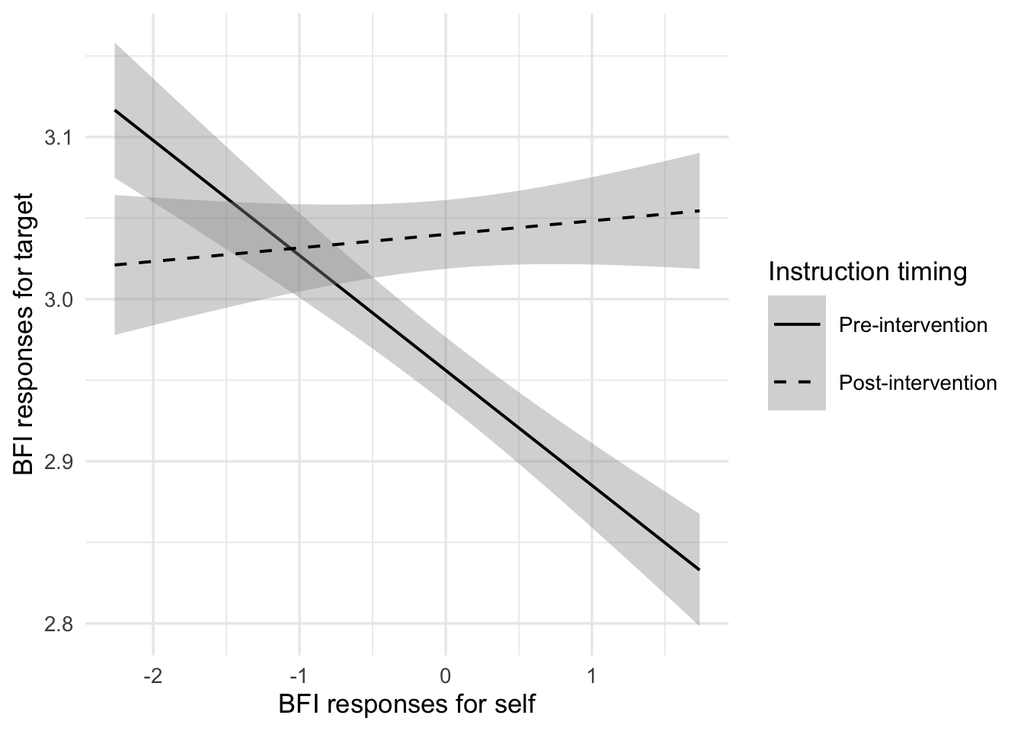

```r
ggplot(model_data, aes(self_c, target_bfi_value, group = target_number_collapsed)) +
    geom_smooth(method = "lm",
                size = .7,
                colour = "black",
                aes(linetype = target_number_collapsed)) +
    theme_minimal(base_size = 13) +
    theme(legend.key.size = unit(1, "cm")) +
    labs(
      x = "BFI responses for self",
      y = "BFI responses for target"
      ) +
    scale_linetype_manual("Instruction timing",
                        breaks = c("target_1", "target_2"),
                       labels = c("Pre-intervention",
                                  "Post-intervention"),
                       values = c("solid",
                                  "dashed"))
```

## Identification main effect

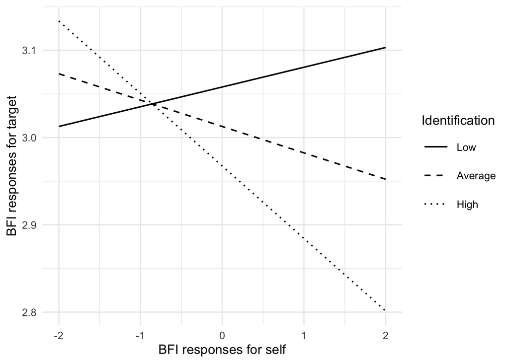

```r
# describe(model_data$ingroup_ident_c)

effects_data_ident <- effect("self_c:ingroup_ident_c",
                         xlevels = list(ingroup_ident_c = c(-0.95, 0, 0.95)),
                         mod = mod_vartest_ident)

effects_data_ident <- as.data.frame(effects_data_ident)
effects_data_ident$ingroup_ident_c <- as.factor(effects_data_ident$ingroup_ident_c)


ggplot(effects_data_ident, aes(self_c, fit, group = ingroup_ident_c)) +
    geom_smooth(method = "lm",
                size = .7,
                colour = "black",
                se = FALSE,
                aes(linetype = ingroup_ident_c)) +
    theme_minimal(base_size = 13) +
    theme(legend.key.size = unit(1, "cm")) +
    scale_linetype_manual("Identification",
                        breaks = c(-0.95, 0, 0.95),
                       labels = c("Low",
                                  "Average",
                                  "High"),
                       values = c("solid",
                                  "dashed",
                                  "dotted")) +
    labs(x = "BFI responses for self",
       y = "BFI responses for target")
```

## Threat main effect

```r
describe(model_data$threat_c)
```

```
##    vars     n mean  sd median trimmed  mad   min  max range  skew kurtosis   se
## X1    1 22712    0 1.3  -0.27    0.07 1.48 -2.27 1.73     4 -0.17    -1.07 0.01
```

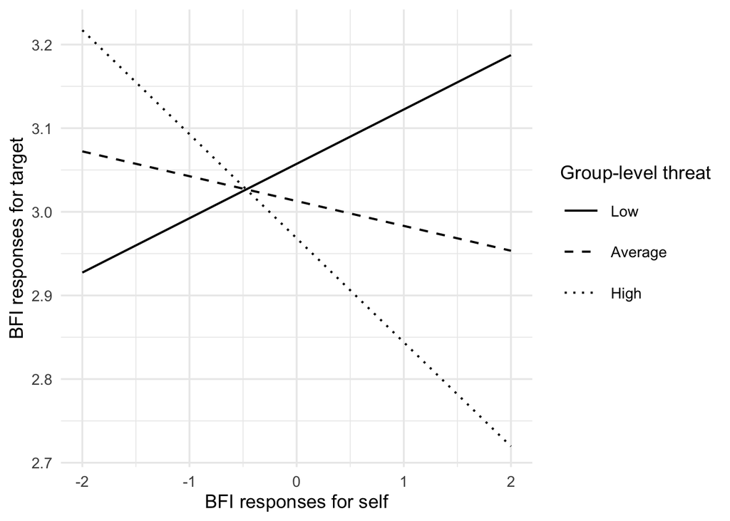

```r
effects_data_threat <- effect("self_c:threat_c",
                         xlevels = list(threat_c = c(-1.3, 0, 1.3)),
                         mod = mod_vartest_threat)

effects_data_threat <- as.data.frame(effects_data_threat)
effects_data_threat$threat_c <- as.factor(effects_data_threat$threat_c)

ggplot(effects_data_threat, aes(self_c, fit, group = threat_c)) +
    geom_smooth(method = "lm",
                size = .7,
                se = FALSE,
                colour = "black",
                aes(linetype = threat_c)) +
    theme_minimal(base_size = 13) +
    theme(legend.key.size = unit(1, "cm")) +
  scale_linetype_manual("Group-level threat",
                        breaks = c(-1.3, 0, 1.3),
                       labels = c("Low",
                                  "Average",
                                  "High"),
                       values = c("solid",
                                  "dashed",
                                  "dotted")) +
    labs(x = "BFI responses for self",
       y = "BFI responses for target")
```

# Exploratory models

## Interaction of threat & identification

```r
mod_vartest_int <- lmer(target_bfi_value ~ self_c*target_number_collapsed*threat_c*ingroup_ident_c + (self_c |sub_id), data = model_data)

#anova(mod_vartest_threat, mod_vartest_int)

#anova(mod_vartest_ident, mod_vartest_int)

tab_model(mod_vartest_int,
          digits = 3)
```

|  | target_bfi_value |  |  |
| --- | --- | --- | --- |
| Predictors | Estimates | CI | p |
| (Intercept) | 2.974 | 2.945 – 3.004 | **<0.001** |
| self c | -0.073 | -0.107 – -0.039 | **<0.001** |
| target number collapsed [target 2] | 0.086 | 0.057 – 0.115 | **<0.001** |
| threat c | -0.027 | -0.050 – -0.003 | **0.027** |
| ingroup ident c | -0.044 | -0.076 – -0.012 | **0.007** |
| self c * target number collapsed [target 2] | 0.081 | 0.058 – 0.104 | **<0.001** |
| self c * threat c | -0.066 | -0.092 – -0.039 | **<0.001** |
| target number collapsed [target 2] * threat c | -0.001 | -0.024 – 0.022 | 0.935 |
| self c * ingroup ident c | -0.027 | -0.063 – 0.009 | 0.136 |
| target number collapsed [target 2] * ingroup ident c | 0.012 | -0.018 – 0.043 | 0.426 |
| threat c * ingroup ident c | -0.009 | -0.030 – 0.012 | 0.401 |
| (self c * target number collapsed [target 2]) * threat c | 0.000 | -0.017 – 0.018 | 0.958 |
| (self c * target number collapsed [target 2]) * ingroup ident c | 0.002 | -0.022 – 0.025 | 0.873 |
| (self c * threat c) * ingroup ident c | 0.009 | -0.014 – 0.033 | 0.443 |
| (target number collapsed [target 2] * threat c) * ingroup ident c | -0.005 | -0.025 – 0.015 | 0.647 |
| (self c * target number collapsed [target 2] *threat c)* ingroup ident c | -0.004 | -0.019 – 0.012 | 0.643 |
| Random Effects |  |  |  |
| σ<sup>2</sup> | 1.14 |  |  |
| τ<sub>00</sub> <sub>sub_id</sub> | 0.03 |  |  |
| τ<sub>11</sub> <sub>sub_id.self_c</sub> | 0.06 |  |  |
| ρ<sub>01</sub> <sub>sub_id</sub> | 0.30 |  |  |
| ICC | 0.11 |  |  |
| N <sub>sub_id</sub> | 300 |  |  |
| Observations | 22712 |  |  |
| Marginal R<sup>2</sup> / Conditional R<sup>2</sup> | 0.020 / 0.124 |  |  |

### Simple Slopes

```r
emms_slopes_threat_int <- emtrends(mod_vartest_int, ~ threat_c,
                              var ="self_c",
                              at = threat_levels)

emms_slopes_threat_int
```

```
##  threat_c self_c.trend     SE  df asymp.LCL asymp.UCL
##      -1.3       0.0523 0.0237 Inf   0.00579  0.098820
##       0.0      -0.0327 0.0163 Inf  -0.06461 -0.000869
##       1.3      -0.1178 0.0228 Inf  -0.16252 -0.073064
##
## Results are averaged over the levels of: target_number_collapsed
## Degrees-of-freedom method: asymptotic
## Confidence level used: 0.95
```

#### With p-values

```r
test(emms_slopes_threat_int)
```

```
##  threat_c self_c.trend     SE  df z.ratio p.value
##      -1.3       0.0523 0.0237 Inf   2.204  0.0275
##       0.0      -0.0327 0.0163 Inf  -2.013  0.0441
##       1.3      -0.1178 0.0228 Inf  -5.162  <.0001
##
## Results are averaged over the levels of: target_number_collapsed
## Degrees-of-freedom method: asymptotic
```

#### Pairwise comparisons

```r
pairs(emms_slopes_threat_int)
```

```
##  contrast     estimate     SE  df z.ratio p.value
##  (-1.3) - 0      0.085 0.0167 Inf   5.105  <.0001
##  (-1.3) - 1.3    0.170 0.0333 Inf   5.105  <.0001
##  0 - 1.3         0.085 0.0167 Inf   5.105  <.0001
##
## Results are averaged over the levels of: target_number_collapsed
## Degrees-of-freedom method: asymptotic
## P value adjustment: tukey method for comparing a family of 3 estimates
```

## Order

```r
mod_vartest_order <- lmer(target_bfi_value ~ self_c*target_number_collapsed*condition_order + (self_c |sub_id), data = model_data)

#anova(model_base, mod_vartest_order)

tab_model(mod_vartest_order,
          digits = 3)
```

|  | target_bfi_value |  |  |
| --- | --- | --- | --- |
| Predictors | Estimates | CI | p |
| (Intercept) | 2.943 | 2.901 – 2.985 | **<0.001** |
| self c | -0.078 | -0.126 – -0.030 | **0.002** |
| target number collapsed [target 2] | 0.118 | 0.079 – 0.157 | **<0.001** |
| condition order [o2] | 0.055 | -0.004 – 0.114 | 0.067 |
| self c * target number collapsed [target 2] | 0.141 | 0.111 – 0.171 | **<0.001** |
| self c * condition order [o2] | 0.017 | -0.051 – 0.085 | 0.627 |
| target number collapsed [target 2] * condition order [o2] | -0.068 | -0.124 – -0.013 | **0.016** |
| (self c * target number collapsed [target 2]) * condition order [o2] | -0.126 | -0.169 – -0.083 | **<0.001** |
| Random Effects |  |  |  |
| σ<sup>2</sup> | 1.13 |  |  |
| τ<sub>00</sub> <sub>sub_id</sub> | 0.04 |  |  |
| τ<sub>11</sub> <sub>sub_id.self_c</sub> | 0.07 |  |  |
| ρ<sub>01</sub> <sub>sub_id</sub> | 0.37 |  |  |
| ICC | 0.12 |  |  |
| N <sub>sub_id</sub> | 300 |  |  |
| Observations | 22712 |  |  |
| Marginal R<sup>2</sup> / Conditional R<sup>2</sup> | 0.007 / 0.125 |  |  |

UH-OH - The target order mattered….

### Simple Slopes

```r
list(ingroup_ident_c = c(-0.95, 0, 0.95))
```

```
## $ingroup_ident_c
## [1] -0.95  0.00  0.95
```

```r
emms_slopes_order <- emtrends(mod_vartest_order, ~ target_number_collapsed*condition_order,
                              var ="self_c",
                              at = list(condition_order = c("o1", "o2")))

emms_slopes_order
```

```
##  target_number_collapsed condition_order self_c.trend     SE  df asymp.LCL
##  target_1                o1                   -0.0776 0.0246 Inf   -0.1258
##  target_2                o1                    0.0631 0.0246 Inf    0.0150
##  target_1                o2                   -0.0607 0.0247 Inf   -0.1092
##  target_2                o2                   -0.0460 0.0247 Inf   -0.0945
##  asymp.UCL
##   -0.02953
##    0.11124
##   -0.01221
##    0.00248
##
## Degrees-of-freedom method: asymptotic
## Confidence level used: 0.95
```

#### With p-values

```r
test(emms_slopes_order)
```

```
##  target_number_collapsed condition_order self_c.trend     SE  df z.ratio
##  target_1                o1                   -0.0776 0.0246 Inf  -3.163
##  target_2                o1                    0.0631 0.0246 Inf   2.571
##  target_1                o2                   -0.0607 0.0247 Inf  -2.453
##  target_2                o2                   -0.0460 0.0247 Inf  -1.860
##  p.value
##   0.0016
##   0.0102
##   0.0142
##   0.0629
##
## Degrees-of-freedom method: asymptotic
```

#### Pairwise comparisons

```r
pairs(emms_slopes_order)
```

```
##  contrast                  estimate     SE  df z.ratio p.value
##  target_1 o1 - target_2 o1  -0.1408 0.0154 Inf  -9.123  <.0001
##  target_1 o1 - target_1 o2  -0.0169 0.0349 Inf  -0.486  0.9623
##  target_1 o1 - target_2 o2  -0.0316 0.0349 Inf  -0.907  0.8010
##  target_2 o1 - target_1 o2   0.1238 0.0349 Inf   3.552  0.0022
##  target_2 o1 - target_2 o2   0.1091 0.0349 Inf   3.131  0.0094
##  target_1 o2 - target_2 o2  -0.0147 0.0159 Inf  -0.926  0.7907
##
## Degrees-of-freedom method: asymptotic
## P value adjustment: tukey method for comparing a family of 4 estimates
```

### Exploring if order effect is due to participant gender

```r
# Model was rank deficient with other categories
gender_filtered <- model_data %>%
  filter(gender == "Female" | gender == "Male")

mod_vartest_order2 <- lmer(target_bfi_value ~ self_c*target_number_collapsed*condition_order*gender + (self_c |sub_id), data = gender_filtered)

tab_model(mod_vartest_order2,
          digits = 3)
```

|  | target_bfi_value |  |  |
| --- | --- | --- | --- |
| Predictors | Estimates | CI | p |
| (Intercept) | 2.938 | 2.886 – 2.989 | **<0.001** |
| self c | -0.089 | -0.147 – -0.031 | **0.003** |
| target number collapsed [target 2] | 0.118 | 0.070 – 0.167 | **<0.001** |
| condition order [o2] | 0.031 | -0.040 – 0.103 | 0.391 |
| gender [Male] | 0.005 | -0.087 – 0.096 | 0.920 |
| self c * target number collapsed [target 2] | 0.138 | 0.101 – 0.176 | **<0.001** |
| self c * condition order [o2] | -0.003 | -0.084 – 0.078 | 0.943 |
| target number collapsed [target 2] * condition order [o2] | -0.053 | -0.120 – 0.014 | 0.121 |
| self c * gender [Male] | 0.041 | -0.062 – 0.145 | 0.435 |
| target number collapsed [target 2] * gender [Male] | 0.037 | -0.049 – 0.122 | 0.399 |
| condition order [o2] * gender [Male] | 0.101 | -0.031 – 0.232 | 0.133 |
| (self c * target number collapsed [target 2]) * condition order [o2] | -0.145 | -0.197 – -0.093 | **<0.001** |
| (self c * target number collapsed [target 2]) * gender [Male] | 0.020 | -0.047 – 0.087 | 0.556 |
| (self c * condition order [o2]) * gender [Male] | 0.066 | -0.083 – 0.215 | 0.383 |
| (target number collapsed [target 2] * condition order [o2]) * gender [Male] | -0.087 | -0.209 – 0.035 | 0.164 |
| (self c * target number collapsed [target 2] *condition order [o2])* gender [Male] | 0.064 | -0.033 – 0.161 | 0.195 |
| Random Effects |  |  |  |
| σ<sup>2</sup> | 1.13 |  |  |
| τ<sub>00</sub> <sub>sub_id</sub> | 0.04 |  |  |
| τ<sub>11</sub> <sub>sub_id.self_c</sub> | 0.07 |  |  |
| ρ<sub>01</sub> <sub>sub_id</sub> | 0.35 |  |  |
| ICC | 0.12 |  |  |
| N <sub>sub_id</sub> | 291 |  |  |
| Observations | 22032 |  |  |
| Marginal R<sup>2</sup> / Conditional R<sup>2</sup> | 0.011 / 0.126 |  |  |

First model is rank deficient, probably because of the categories that were underpowered (7, 1, 1). Gender does not moderate this effect.

### Liberal participants only

```r
lib_only <- model_data %>%
  filter(cand_pref == "Not Trump Supporter")

mod_vartest_order_lib <- lmer(target_bfi_value ~ self_c*target_number_collapsed*condition_order + (self_c |sub_id), data = lib_only)

#anova(model_base, mod_vartest_order)

tab_model(mod_vartest_order_lib,
          digits = 3)
```

|  | target_bfi_value |  |  |
| --- | --- | --- | --- |
| Predictors | Estimates | CI | p |
| (Intercept) | 2.937 | 2.894 – 2.981 | **<0.001** |
| self c | -0.106 | -0.155 – -0.057 | **<0.001** |
| target number collapsed [target 2] | 0.123 | 0.082 – 0.164 | **<0.001** |
| condition order [o2] | 0.035 | -0.026 – 0.097 | 0.256 |
| self c * target number collapsed [target 2] | 0.168 | 0.136 – 0.200 | **<0.001** |
| self c * condition order [o2] | 0.012 | -0.058 – 0.081 | 0.741 |
| target number collapsed [target 2] * condition order [o2] | -0.060 | -0.118 – -0.002 | **0.043** |
| (self c * target number collapsed [target 2]) * condition order [o2] | -0.140 | -0.185 – -0.094 | **<0.001** |
| Random Effects |  |  |  |
| σ<sup>2</sup> | 1.14 |  |  |
| τ<sub>00</sub> <sub>sub_id</sub> | 0.04 |  |  |
| τ<sub>11</sub> <sub>sub_id.self_c</sub> | 0.07 |  |  |
| ρ<sub>01</sub> <sub>sub_id</sub> | 0.32 |  |  |
| ICC | 0.11 |  |  |
| N <sub>sub_id</sub> | 274 |  |  |
| Observations | 20744 |  |  |
| Marginal R<sup>2</sup> / Conditional R<sup>2</sup> | 0.011 / 0.121 |  |  |

## Order x threat

```r
mod_vartest_order_threat <- lmer(target_bfi_value ~ self_c*target_number_collapsed*condition_order*threat_c + (self_c |sub_id), data = model_data)

#anova(model_base, mod_vartest_order)

tab_model(mod_vartest_order_threat,
          digits = 3)
```

|  | target_bfi_value |  |  |
| --- | --- | --- | --- |
| Predictors | Estimates | CI | p |
| (Intercept) | 2.946 | 2.905 – 2.987 | **<0.001** |
| self c | -0.071 | -0.117 – -0.025 | **0.002** |
| target number collapsed [target 2] | 0.120 | 0.081 – 0.160 | **<0.001** |
| condition order [o2] | 0.048 | -0.010 – 0.107 | 0.104 |
| threat c | -0.028 | -0.060 – 0.004 | 0.083 |
| self c * target number collapsed [target 2] | 0.143 | 0.112 – 0.173 | **<0.001** |
| self c * condition order [o2] | 0.004 | -0.061 – 0.069 | 0.895 |
| target number collapsed [target 2] * condition order [o2] | -0.069 | -0.124 – -0.013 | **0.015** |
| self c * threat c | -0.079 | -0.114 – -0.043 | **<0.001** |
| target number collapsed [target 2] * threat c | -0.016 | -0.046 – 0.014 | 0.293 |
| condition order [o2] * threat c | -0.011 | -0.056 – 0.034 | 0.628 |
| (self c * target number collapsed [target 2]) * condition order [o2] | -0.128 | -0.171 – -0.084 | **<0.001** |
| (self c * target number collapsed [target 2]) * threat c | -0.010 | -0.033 – 0.013 | 0.402 |
| (self c * condition order [o2]) * threat c | 0.011 | -0.039 – 0.061 | 0.665 |
| (target number collapsed [target 2] * condition order [o2]) * threat c | 0.031 | -0.012 – 0.074 | 0.155 |
| (self c * target number collapsed [target 2] *condition order [o2])* threat c | 0.015 | -0.018 – 0.049 | 0.378 |
| Random Effects |  |  |  |
| σ<sup>2</sup> | 1.14 |  |  |
| τ<sub>00</sub> <sub>sub_id</sub> | 0.04 |  |  |
| τ<sub>11</sub> <sub>sub_id.self_c</sub> | 0.06 |  |  |
| ρ<sub>01</sub> <sub>sub_id</sub> | 0.31 |  |  |
| ICC | 0.11 |  |  |
| N <sub>sub_id</sub> | 300 |  |  |
| Observations | 22712 |  |  |
| Marginal R<sup>2</sup> / Conditional R<sup>2</sup> | 0.020 / 0.126 |  |  |

## Covid 1

```r
mod_vartest_covid1  <- lmer(target_bfi_value ~ self_c*target_number_collapsed*covid1 + (self_c |sub_id), data = model_data)

#anova(model_base, mod_vartest_covid1)
```

Adding first Covid filler question (whether or not they had it/knew someone who did OR did not) did not moderate anything, so did not look at results. A surprising number of people fell into the first category.

## Covid 2

```r
mod_vartest_covid2  <- lmer(target_bfi_value ~ self_c*target_number_collapsed*covid2 + (self_c |sub_id), data = model_data)

#anova(model_base, mod_vartest_covid2)
```

Also not significantly different from the base model.

## Covid 3

```r
mod_vartest_covid3  <- lmer(target_bfi_value ~ self_c*target_number_collapsed*covid3 + (self_c |sub_id), data = model_data)

#anova(model_base, mod_vartest_covid3)

tab_model(mod_vartest_covid3,
          digits = 3)
```

|  | target_bfi_value |  |  |
| --- | --- | --- | --- |
| Predictors | Estimates | CI | p |
| (Intercept) | 3.005 | 2.962 – 3.047 | **<0.001** |
| self c | -0.018 | -0.068 – 0.031 | 0.465 |
| target number collapsed [target 2] | 0.078 | 0.037 – 0.118 | **<0.001** |
| covid3 [Economic] | 0.081 | -0.055 – 0.218 | 0.242 |
| covid3 [Health] | -0.082 | -0.142 – -0.022 | **0.007** |
| covid3 [Neither] | 0.098 | -0.197 – 0.393 | 0.514 |
| self c * target number collapsed [target 2] | 0.080 | 0.048 – 0.113 | **<0.001** |
| self c * covid3 [Economic] | 0.134 | -0.024 – 0.293 | 0.097 |
| self c * covid3 [Health] | -0.120 | -0.189 – -0.051 | **0.001** |
| self c * covid3 [Neither] | -0.102 | -0.456 – 0.252 | 0.573 |
| target number collapsed [target 2] * covid3 [Economic] | 0.032 | -0.099 – 0.162 | 0.636 |
| target number collapsed [target 2] * covid3 [Health] | 0.009 | -0.048 – 0.066 | 0.756 |
| target number collapsed [target 2] * covid3 [Neither] | 0.034 | -0.246 – 0.314 | 0.812 |
| (self c * target number collapsed [target 2]) * covid3 [Economic] | -0.082 | -0.188 – 0.024 | 0.129 |
| (self c * target number collapsed [target 2]) * covid3 [Health] | 0.003 | -0.042 – 0.048 | 0.901 |
| (self c * target number collapsed [target 2]) * covid3 [Neither] | 0.132 | -0.092 – 0.357 | 0.249 |
| Random Effects |  |  |  |
| σ<sup>2</sup> | 1.14 |  |  |
| τ<sub>00</sub> <sub>sub_id</sub> | 0.03 |  |  |
| τ<sub>11</sub> <sub>sub_id.self_c</sub> | 0.07 |  |  |
| ρ<sub>01</sub> <sub>sub_id</sub> | 0.32 |  |  |
| ICC | 0.11 |  |  |
| N <sub>sub_id</sub> | 300 |  |  |
| Observations | 22712 |  |  |
| Marginal R<sup>2</sup> / Conditional R<sup>2</sup> | 0.012 / 0.124 |  |  |

## Voting preference

```r
mod_vartest_cand <- lmer(target_bfi_value ~ self_c*target_number_collapsed*cand_pref + (self_c |sub_id), data = model_data)

#anova(model_base, mod_vartest_cand)

tab_model(mod_vartest_cand,
          digits = 3)
```

|  | target_bfi_value |  |  |
| --- | --- | --- | --- |
| Predictors | Estimates | CI | p |
| (Intercept) | 2.955 | 2.924 – 2.986 | **<0.001** |
| self c | -0.101 | -0.136 – -0.066 | **<0.001** |
| target number collapsed [target 2] | 0.093 | 0.064 – 0.122 | **<0.001** |
| cand pref [Trump Supporter] | 0.195 | 0.091 – 0.299 | **<0.001** |
| self c * target number collapsed [target 2] | 0.099 | 0.076 – 0.122 | **<0.001** |
| self c * cand pref [Trump Supporter] | 0.355 | 0.237 – 0.474 | **<0.001** |
| target number collapsed [target 2] * cand pref [Trump Supporter] | -0.126 | -0.225 – -0.027 | **0.013** |
| (self c * target number collapsed [target 2]) * cand pref [Trump Supporter] | -0.228 | -0.304 – -0.151 | **<0.001** |
| Random Effects |  |  |  |
| σ<sup>2</sup> | 1.13 |  |  |
| τ<sub>00</sub> <sub>sub_id</sub> | 0.04 |  |  |
| τ<sub>11</sub> <sub>sub_id.self_c</sub> | 0.07 |  |  |
| ρ<sub>01</sub> <sub>sub_id</sub> | 0.33 |  |  |
| ICC | 0.11 |  |  |
| N <sub>sub_id</sub> | 300 |  |  |
| Observations | 22712 |  |  |
| Marginal R<sup>2</sup> / Conditional R<sup>2</sup> | 0.013 / 0.125 |  |  |

This model is significantly different and all the effects are significant… HOWEVER, the groups are highly different in numbers and this makes me very uncomfortable with these results. We should collect equal numbers to analyze this question.

**Not going to look at visualizations because I do not think these are reliable.

# Exploratory visualizations

## Threat accounting for identification

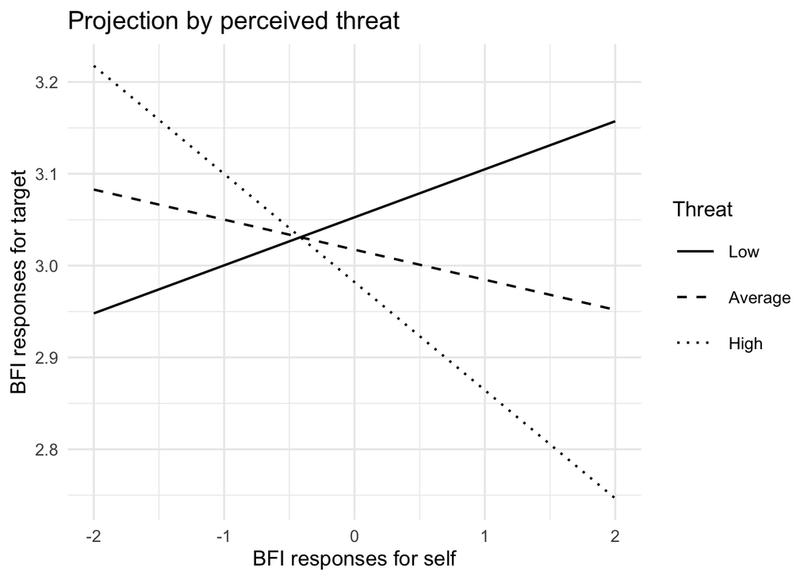

```r
effects_data_threat_int <- effect("self_c:threat_c",
                         xlevels = list(threat_c = c(-1.3, 0, 1.3)),
                         mod = mod_vartest_int)

effects_data_threat_int <- as.data.frame(effects_data_threat_int)
effects_data_threat_int$threat_c <- as.factor(effects_data_threat_int$threat_c)

ggplot(effects_data_threat_int, aes(self_c, fit, group = threat_c)) +
    geom_smooth(method = "lm",
                size = .7,
                se = FALSE,
                colour = "black",
                aes(linetype = threat_c)) +
    theme_minimal(base_size = 13) +
    theme(legend.key.size = unit(1, "cm")) +
  scale_linetype_manual("Threat",
                        breaks = c(-1.3, 0, 1.3),
                       labels = c("Low",
                                  "Average",
                                  "High"),
                       values = c("solid",
                                  "dashed",
                                  "dotted")) +
    labs(title = "Projection by perceived threat",
       x = "BFI responses for self",
       y = "BFI responses for target")
```

Main effect of threat after accounting for in-group identification seems unaffected.

## Interaction of target number and order

### Both liberals and conservatives

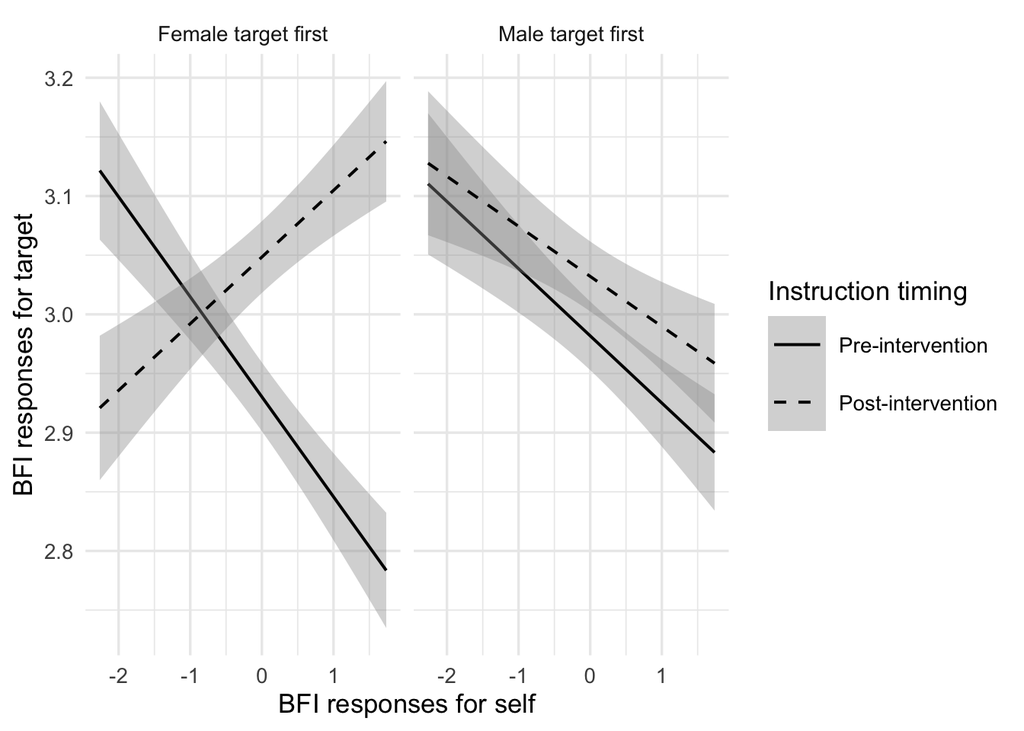

```r
order_label <- c("o1" = "Female target first",
                 "o2" = "Male target first")

ggplot(model_data, aes(self_c,
                       target_bfi_value,
                       group = target_number_collapsed)) +
    geom_smooth(method = "lm",
                size = .7,
                colour = "black",
                aes(linetype = target_number_collapsed)) +
  facet_wrap(~condition_order,
             labeller = labeller(condition_order = order_label)) +
  theme_minimal(base_size = 13) +
  theme(legend.key.size = unit(1, "cm")) +
  scale_linetype_manual("Instruction timing",
                       labels = c("Pre-intervention",
                                  "Post-intervention"),
                       values = c("solid",
                                  "dashed")) +
    labs(x = "BFI responses for self",
       y = "BFI responses for target")
```

### Liberals only

mod_vartest_order_lib

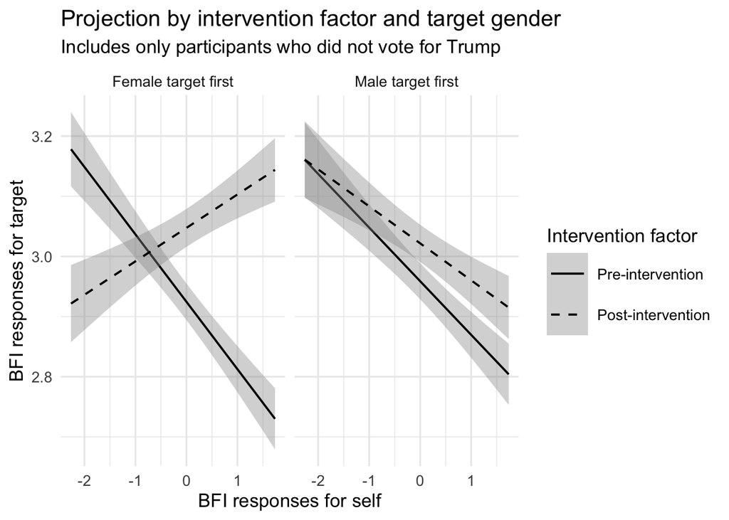

```r
ggplot(lib_only, aes(self_c,
                       target_bfi_value,
                       group = target_number_collapsed)) +
    geom_smooth(method = "lm",
                size = .7,
                colour = "black",
                aes(linetype = target_number_collapsed)) +
  facet_wrap(~condition_order,
             labeller = labeller(condition_order = order_label)) +
  theme_minimal(base_size = 13) +
  theme(legend.key.size = unit(1, "cm")) +
  scale_linetype_manual("Intervention factor",
                       labels = c("Pre-intervention",
                                  "Post-intervention"),
                       values = c("solid",
                                  "dashed")) +
    labs(title = "Projection by intervention factor and target gender",
         subtitle = "Includes only participants who did not vote for Trump",
       x = "BFI responses for self",
       y = "BFI responses for target")
```

## Main effect of Covid 3

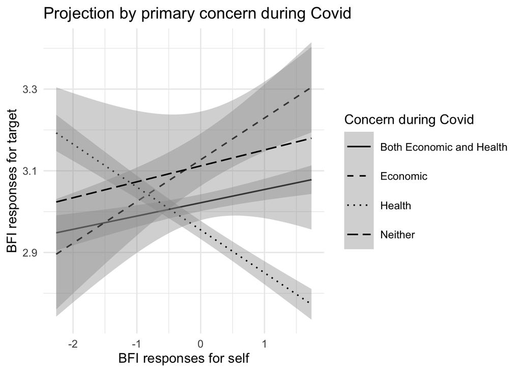

```r
ggplot(model_data, aes(self_c,
                       target_bfi_value,
                       group = covid3)) +
    geom_smooth(method = "lm",
                size = .7,
                colour = "black",
                aes(linetype = covid3)) +
  theme_minimal(base_size = 13) +
  theme(legend.key.size = unit(1, "cm")) +
  scale_linetype_manual("Concern during Covid",
                       labels = c("Both Economic and Health",
                                  "Economic",
                                  "Health",
                                  "Neither"),
                       values = c("solid",
                                  "dashed",
                                  "dotted",
                                  "longdash")) +
    labs(title = "Projection by primary concern during Covid",
       x = "BFI responses for self",
       y = "BFI responses for target")
```

People whose main concern during Covid was health counter-projected across target variables, while all other participants projected positively to some degree.